# SDGB-7844 Homework #4: Probability Distributions

Fabian Hansch Mauritzson

## The Geometric Probability Distribution & Weak Law of Large Numbers

A random variable with the geometric probability distribution is associated with an experiment that shares some of the characteristics of a binomial experiment. This experiment also involves identical and independent trials, each of which can result in one of two outcomes: success or failure. The probability of success is equal to $p$ and is constant from trial to trial. However, instead of the number of successes that occur in $n$ trials, the geometric random variable is the number of trials on which the first success occurs. The geometric probability distribution is often used to model distributions of lengths of waiting times.

Let us roll a $K$ sided die with numbers $1$, . . . , $K$ written on them where $K > 1$. Each number is equally likely to be rolled. Let $X$ be a random variable representing the number of rolls needed to get the number $K$ for the first time. (Note: number of rolls includes the roll where $K$ appears.)

1. On any roll, what is the probability of rolling the value $K$?

1/$K$

2. What are all of the possible values of $X$?

Every positive integer from 1 to infinity.

3. Create a function with arguments, `K` and `simulations`, with `simulations` representing the number of times we should play out this scenario. Your function should return the number of times the die was rolled in order to get the value `K`. (Helpful hint: Try using a while loop)

```r
amount_of_rolls <- function(K, simulations) {
  #Creating the empty vector for the rolls per sim
  rolls <- c()
  for (i in 1:simulations) {
    x <- 0
    rolls_count <- 0
    while(x != K) {
      x <- sample(1:K)

      #Only taking the first value since that's what was rolled
      x <- x[1]
      rolls_count <- rolls_count + 1
      #print(x)
    }
    rolls <- append(rolls, rolls_count)
  }
  return(rolls)
}
```

4. For $K = [2, 6, 12, 15]$ simulate 100 rounds of the scenario and plot each set of results with a bar graph.

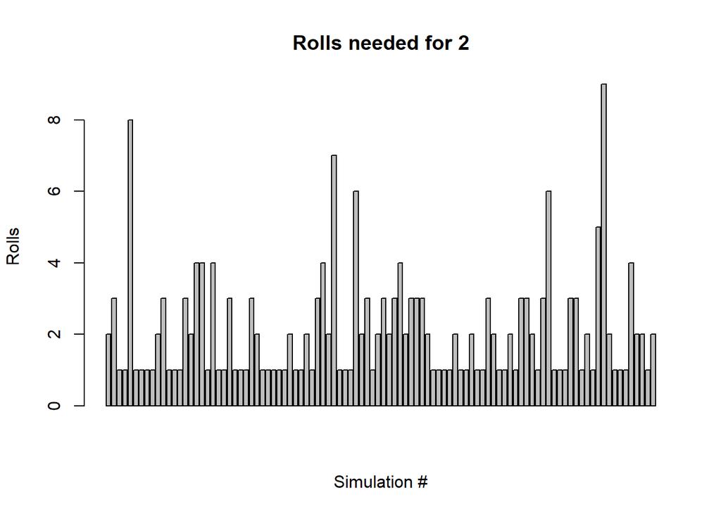

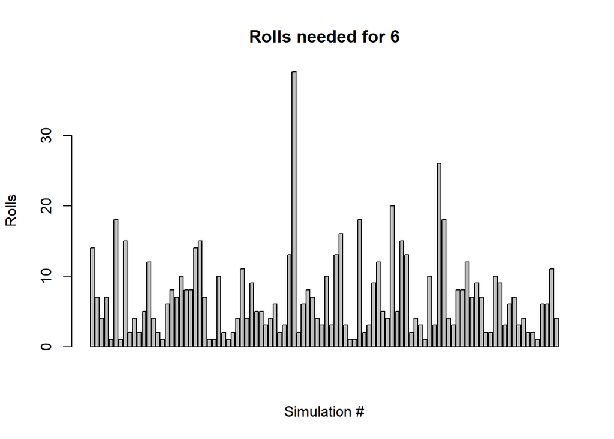

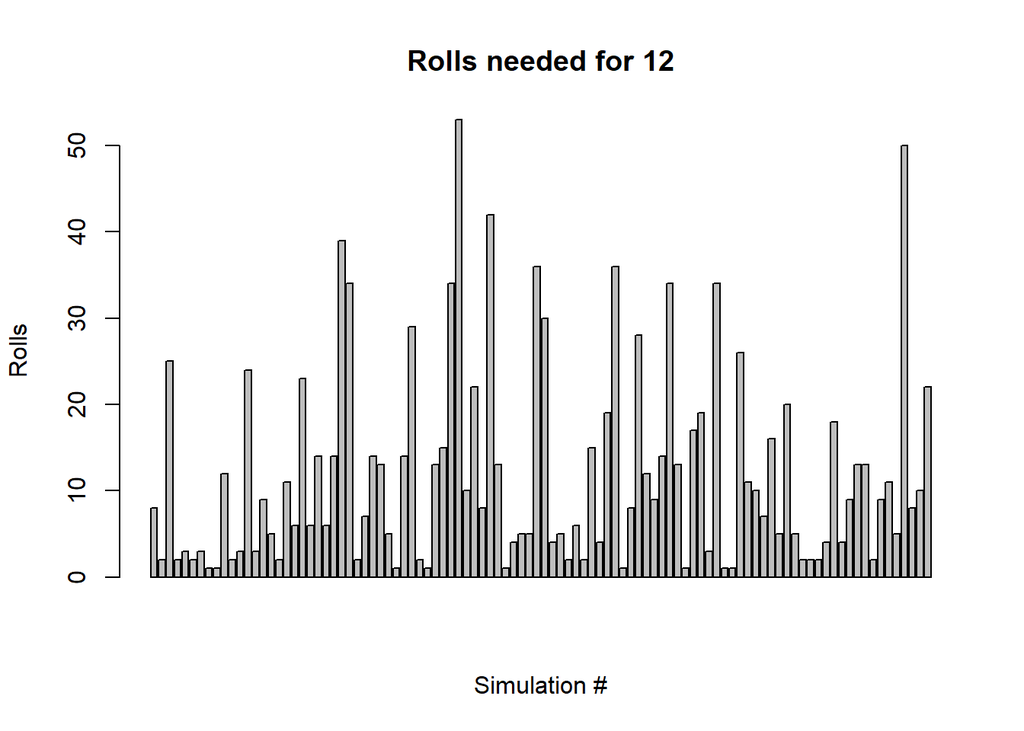

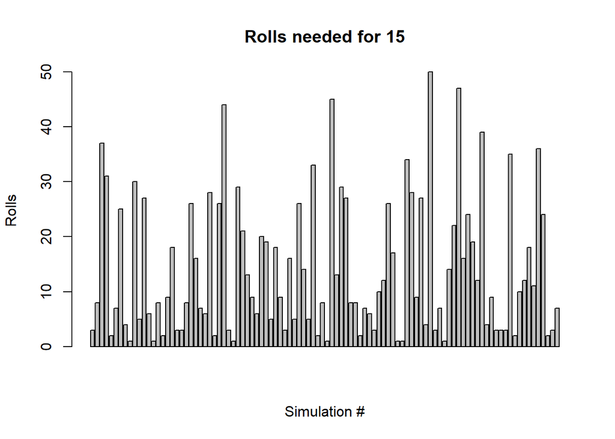

```r
#Input values
K_array <- c(2, 6, 12, 15)
sims <- 100
result <- c()

#For loop which calls the function in Q3 and creates the plots
for (i in 1:length(K_array)) {
  result <- append(result, amount_of_rolls(K_array[i], sims))
  barplot(result, main = paste("Rolls needed for", toString(K_array[i])), xlab = "Simulation #", ylab = "Rolls")
  result <- c()
}
```

```r
#barplot(result)
```

5. Repeat question 4 by simulating 100 new rounds of each scenario and plot the results. Have your results changed? Please explain how they have changed. Why might your results be different?

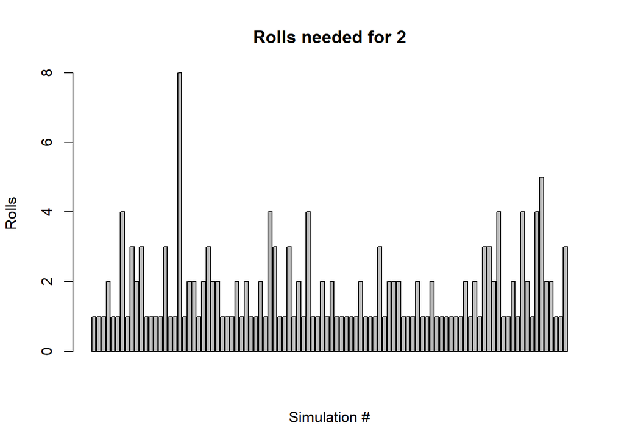

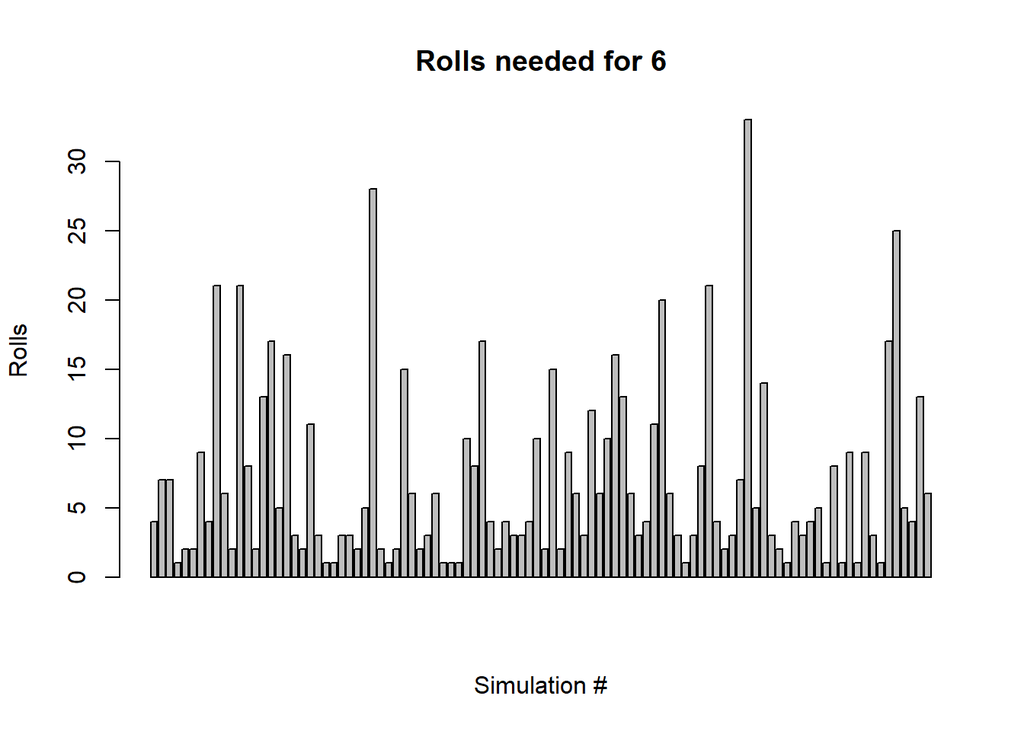

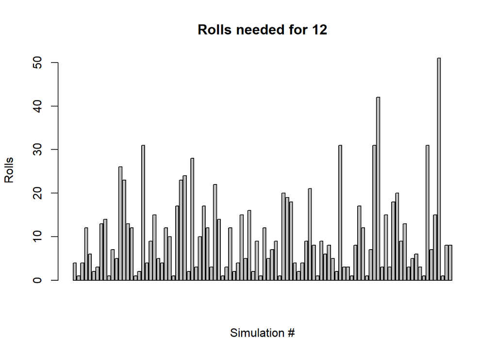

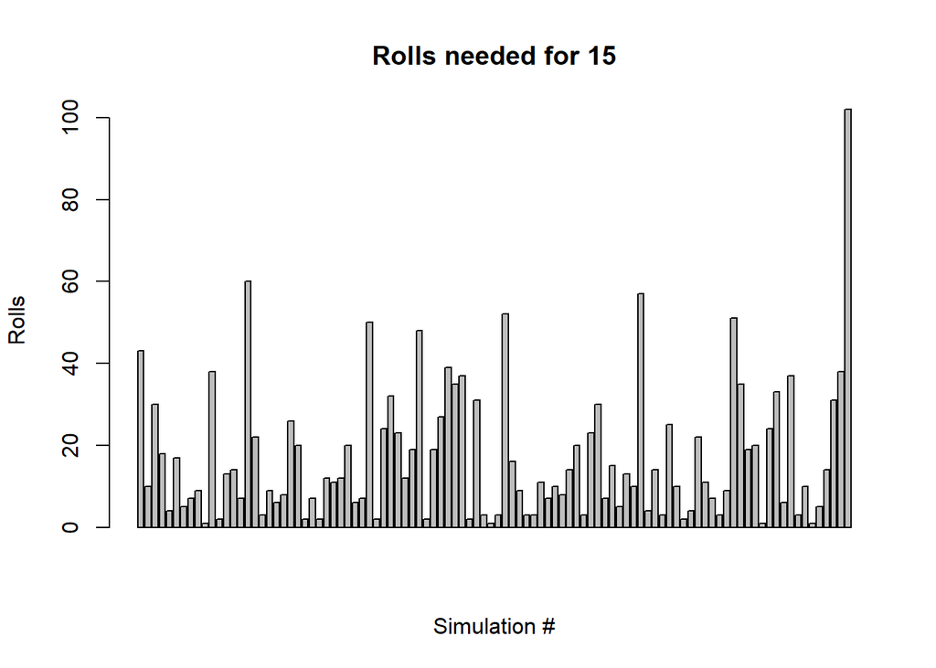

```r
#Input values
K_array <- c(2, 6, 12, 15)
sims <- 100
result <- c()

#For loop which calls the function in Q3 and creates the plots
for (i in 1:length(K_array)) {
  result <- append(result, amount_of_rolls(K_array[i], sims))
  barplot(result, main = paste("Rolls needed for", toString(K_array[i])), xlab = "Simulation #", ylab = "Rolls")
  result <- c()
}
```

6. For each combination of ``simulations` = [100, 1000, 5000, 20000] and $K$ = [2, 6, 12, 15] calculate the average number of rolls required to get $K$. Show these results in a table where your columns are values of n_sim and your rows are values of $K$.

```r
#Input values
K_array <- c(2, 6, 12, 15)
sims <- c(100, 1000, 5000, 20000)
result <- c()
mean_vector <- c()

#Since there are two different vectors with data, nested for loop is required
for (i in 1:length(sims)) {
  for (j in 1:length(K_array)) {
    result <- append(result, amount_of_rolls(K_array[j], sims[i]))
    mean_vector <- append(mean_vector, mean(result))
    result <- c()
  }
  #mean_vector <- append(mean_vector, mean(result))
  #result <- c()
}

#Data cleaning required in order to tabularize it
n_sim100 <- mean_vector[1:4]
n_sim1000 <- mean_vector[5:8]
n_sim5000 <- mean_vector[9:12]
n_sim20000 <- mean_vector[13:16]
df <- data.frame(n_sim100, n_sim1000, n_sim5000, n_sim20000, row.names = c("2", "6", "12", "15"))
df
```

|  | n_sim100 | n_sim1000 | n_sim5000 | n_sim20000 |
| --- | --- | --- | --- | --- |
| 2 | 1.97 | 2.013 | 1.9904 | 1.99590 |
| 6 | 5.36 | 6.097 | 6.0086 | 5.99570 |
| 12 | 10.98 | 11.447 | 12.1388 | 11.98835 |
| 15 | 13.51 | 15.459 | 14.7632 | 14.88485 |

7. How would you describe a general formula for calculating the average number of rolls?